# Basic Tools: ggplot

Stats 422

# Tools - ggplot2

## Data visualization

- Understanding and creating visual representations of data
- R is one of our tools and
- ggplot2 is the package

[figure not shown]

ggplot is part of the Tidyverse in R

- `gg` means “Grammar of Graphics”
- The **Grammar of Graphics** was written by Leland Wilkinson in 1999.
- Wilkinson detailed a comprehensive framework to describe and build a wide range of statistical graphics by breaking down the elements of graphics into a unified system.

## Grammar of Graphics

[figure not shown]

Source: [https://www.stat20.org/](https://stat20.berkeley.edu/spring-2024/2-summarizing-data/03-a-grammar-of-graphics/notes.html)

## Data

- In GG, data is the foundation
- All graphical representation decisions rest on top of it
- All the decisions are data-driven
- Result: meaningful and accurate visual representation of data
- AND a wide variety of graphics

## (aside) Return to Data later

- Present Data Honestly
- Don’t distort data (aggregation, selection)
- Which measure of central tendency is appropriate?
- Cautiously aggregate
- Do show variability
- Use labels

## Aesthetics (Aesthetic Mappings)

- These are the rules related to clarity
- They map (connect) data variables to the visual properties of the graphical elements
- Most frequently - x, y, size, area, color, angle
- The connection of data to graphical elements allow us to see/interpret patterns, trends, and anomalies within the data

## (aside) Return to Aesthetics later

- Perceptual accuracy becomes a consideration here
- Mappings have a hierarchy with respect to human perception
- e.g., position along a scale is more easily interpreted than area
- and area might be more easily interpreted than volume (3D)

## Geometries (geom) include:

- Points, typically used for individual values
- Lines, connect points in some defined order (e.g., time, location)
- Bars, typically used for categories (e.g., pizza types)
- Polygons, use to represent areas (maps)
- Paths, fatter lines, used to represent flows (Sankey)
- and we put these together in a manner like building blocks

## from the ggplot2 cheatsheet

[figure not shown]

## Facets

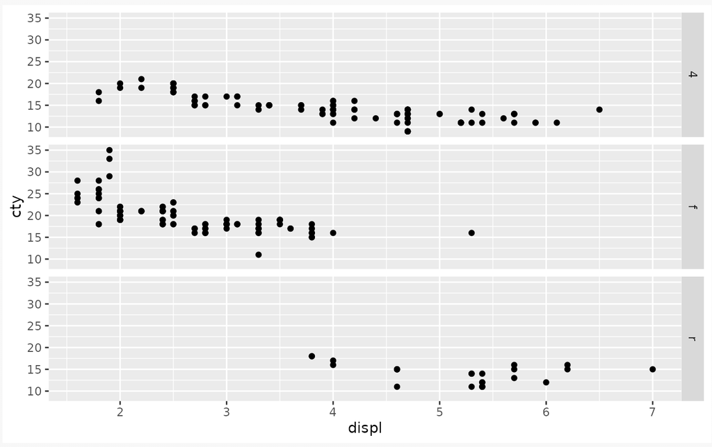

- Conditioning the data
- Simply subsets

## Statistics

- Data can be summarized or modified prior to visualization
  - Aggregation (like sums or means),
  - smoothing
  - transformations
- Can clarify the underlying structure or relationships in data
- Typically see the stat layer inside of a geom

## stat layer example

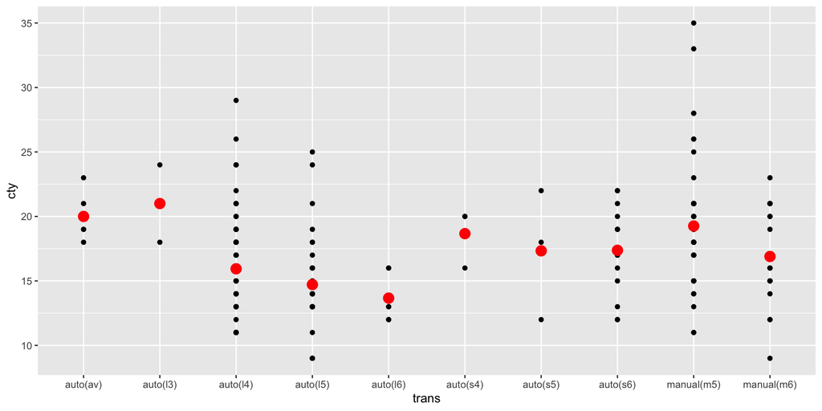

## stat layer example notes

```r
library(ggplot2)
ggplot(mpg, aes(trans, cty)) +
  geom_point() +
  geom_point(stat = "summary", fun = "mean", colour = "red", size = 4)
```

- Note have multiple geoms (one for the original points and one for the transformed). We have one aes(), think of it as “global”

## Coordinates and scales

- Scaling (linear, logarithmic, etc.)
- Coordinate systems (Cartesian, polar, etc.).
- They influence the position of data points (and the interpretation).

## Themes

- Control the overall “look” (styling) of the graphic
- fonts, colors
- labeling, legends, captioning
- layout etc.

# Activity 1